# Problem 2.1

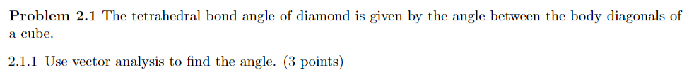

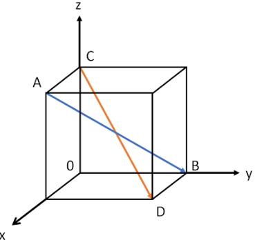

We can find this angle using $\cos\theta = \frac{\vec a \cdot \vec b}{|\vec a||\vec b|}$

$$ \vec a = (1, 1, 1) / \sqrt{3} \\ \vec b = (1, 1, -1) / \sqrt{3}\\ \cos \theta = (1 + 1 -1)/ \sqrt{3}\\ \theta = \cos^{-1} \frac{1}{\sqrt 3} = 1.23 \text{rad} \rightarrow 70.5° $$

Or $180-70.5 = 109.5°$ for the larger angle

# Problem 2.2

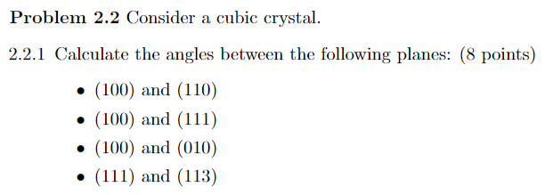

Miller indicies represent a vector which is normal to the associated plane, so we can simply treat them as vectors

1. $$ \begin{pmatrix} 1 \\ 0 \\ 0 \end{pmatrix} \cdot \frac{1}{\sqrt2} \begin{pmatrix} 1 \\ 1 \\ 0 \end{pmatrix} = \frac{1}{\sqrt 2} \\ \theta = \cos ^{-1} \frac{1}{\sqrt 2} = \pi/4 $$
2. $$ \begin{pmatrix} 1 \\ 0 \\ 0 \end{pmatrix} \cdot \frac{1}{\sqrt 3} \begin{pmatrix} 1 \\ 1 \\ 1 \end{pmatrix} = \frac{1}{\sqrt 3} \\ \theta = \cos ^{-1} \frac{1}{\sqrt 3} = 0.95 $$
3. Clearly a right angle $\pi/2$
4. $$ \frac{1}{\sqrt 3} \begin{pmatrix} 1 \\ 1 \\ 1 \end{pmatrix} \cdot \frac{1}{\sqrt {11}} \begin{pmatrix} 1 \\ 1 \\ 3 \end{pmatrix} = \frac{5}{\sqrt{33}} \\ \theta = \cos ^{-1} \frac{5}{\sqrt{33}} = 0.51 $$

# Problem 2.3

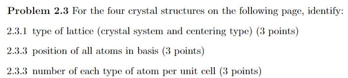

I'll answer 2.3 by the crystal rather than go back and forth. Sorry for breaking order!

CsCl:

- Lattice: Cubic.
- Basis atom Positions:  
  Cl: $\left(\frac{1}{2},\frac{1}{2},\frac{1}{2} \right)$  
  <sup>1/8</sup>Cs: One in each corner $\left\{\left(x_1, x_2, x_3\right) \right\}$ for $x_1, x_2, x_3 \in \{0, 1\}$
- Number: 1x Cs, 1x Cl

NaCl:

- Lattice: FCC
- Basis Positions:  
  <sup>1/8</sup>Cl $\left\{\left(x_1, x_2, x_3\right) \right\}$ for $x_1, x_2, x_3 \in \{0, 1\}$  
  <sup>1/2</sup>Cl $\left\{\left(\frac{1}{2},\frac{1}{2},x \right), \left(\frac{1}{2}, x,\frac{1}{2} \right), \left(x,\frac{1}{2},\frac{1}{2} \right)\right\}$ for $x\in \{0, 1\}$  
  <sup>1/4</sup>Na $\left\{\left(\frac{1}{2},x_1,x_2 \right), \left(x_1, \frac{1}{2}, x_2 \right), \left(x_1, x_2, \frac{1}{2}\right)\right\}$ for $x_1, x_2\in \{0, 1\}$  
  Na $\left(\frac{1}{2},\frac{1}{2},\frac{1}{2} \right)$
- Number: 4x Na, 4x Cl

CaF<sub>2</sub>:

- Lattice: FCC
- Basis Positions:  
  <sup>1/8</sup>Ca $\left\{\left(x_1, x_2, x_3\right) \right\}$ for $x_1, x_2, x_3 \in \{0, 1\}$  
  <sup>1/2</sup>Ca $\left\{\left(\frac{1}{2},\frac{1}{2},x \right), \left(\frac{1}{2}, x,\frac{1}{2} \right), \left(x,\frac{1}{2},\frac{1}{2} \right)\right\}$ for $x\in \{0, 1\}$  
  F $\left\{\left(\frac{2\pm 1}{4},\frac{2\pm 1}{4},\frac{2\pm 1}{4} \right)\right\}$
- Number: 4x Ca, 8x F

BaTiO<sub>3</sub>:

- Lattice: Cubic
- Basis Positions:  
  <sup>1/8</sup>Ba $\left\{\left(x_1, x_2, x_3\right) \right\}$ for $x_1, x_2, x_3 \in \{0, 1\}$  
  <sup>1/2</sup>O $\left\{\left(\frac{1}{2},\frac{1}{2},x \right), \left(\frac{1}{2}, x,\frac{1}{2} \right), \left(x,\frac{1}{2},\frac{1}{2} \right)\right\}$ for $x\in \{0, 1\}$  
  Ti: $\left(\frac{1}{2},\frac{1}{2},\frac{1}{2} \right)$
- Number: 1x Ba, 1x Ti, 3x O

Yay we're done!

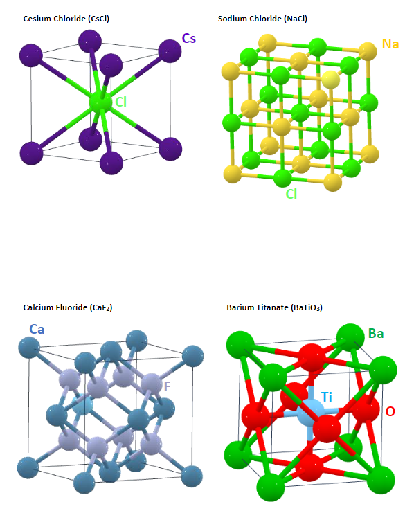